# Chick Growth by Diet

# Final Weight Histogram Grouped by Diet

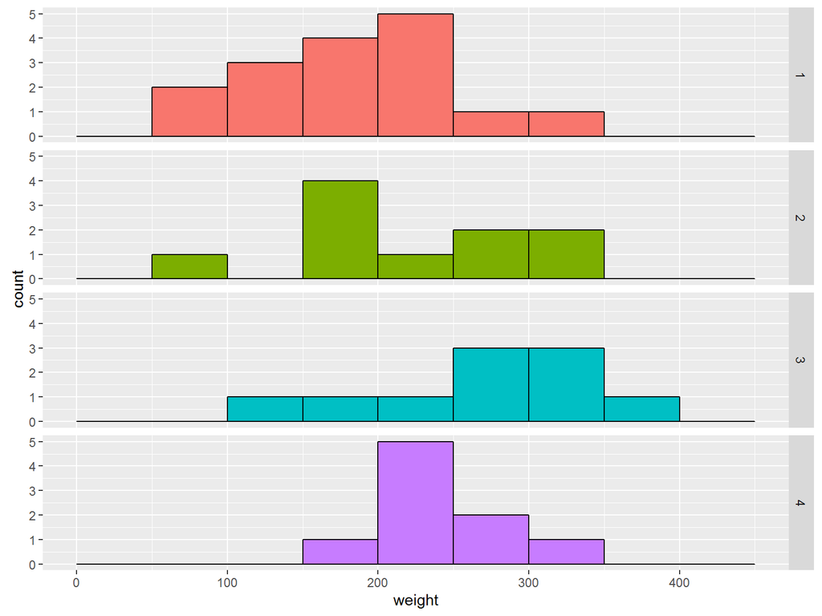

# Survival Rate Grouped by Diet

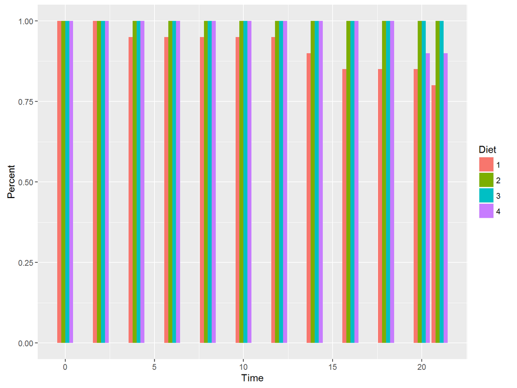

# Summary of Final Weights

### Grouped by Diet

```
##   Diet Num min max     mean median       sd
## 1    1  16  96 305 177.7500  166.0 58.70207
## 2    2  10  74 331 214.7000  212.5 78.13813
## 3    3  10 147 373 270.3000  281.0 71.62254
## 4    4   9 196 322 238.5556  237.0 43.34775
```

# Conclusions

- Diet #3 gives the highest mean and median weight
- Diet #4 is the most consistent with the lowest standard deviation
- Diet #1 has the highest mortality rate
- Diet #4 has the biggest mean weight until day 12 - After which Diet #3 took over

In conclusion, for a fixed Diet, then #3 would be the best choice if selecting for mass, but if uniformity was the desired outcome, then Diet #4 would be the best choice.

It would be worth investigating whether a diet consisting of Diet #4 for the first 10-12 days followed by Diet #3 leads to an increased yield.